# Exploratory data analysis and quality control of TCGA-BRCA RPPA protein data

Training set

Group 2: Multiomics - Parniyan, Sergi, Baizhen, Paula, Yueling

12 November 2026

# 1 Overview

This report documents the exploratory data analysis (EDA) and quality control (QC) of the **reverse-phase protein array (RPPA) data of the TCGA-BRCA training set**. The aim is to decide which proteins and patients can be used in the models, and detect possible technical problems (outlier samples, duplicated or mixed-up samples, batch effects).

**Data**

- Input: `data/data_split/prot.train.rds`, with one row per patient and one column per protein, the clinical data `clin.train.rds` and, for the identity check, the RNA data `rna.train.rds`.
- Values: **log2 relative protein levels**, normalised and **median-centred per protein by TCGA**. Negative values are therefore expected (below the cohort median). Values are comparable between patients for the same protein, but not between different proteins.
- Some proteins are measured in their **phosphorylated** (active) form (e.g. `AKT_pS473`); they are labelled phospho-specific in the plots and tables below.
- Output (written by `02_qc_prot.R`): the filtered data (`prot.train.filtered.rds`) and the QC parameters (`prot_qc_params.rds`: proteins kept and the rule for low-quality samples), used to apply exactly the same QC to the test set.

**General principle**: as in the other QC reports, the goal is to separate technical problems from biological variation. Thresholds are derived from the data whenever possible, and atypical samples are flagged and inspected rather than removed automatically.

All decisions are made on the training set only. This report does not overwrite any file (the saving step is shown but not run). Knit it from the project root with `rmarkdown::render("01_data_preprocess/02_qc_prot.Rmd")`.

# 2 Setup

Packages, a common plot theme and a helper function used in the report.

```r
library(matrixStats)   # fast row/column statistics on matrices
library(ggplot2)
```

```r
theme_qc <- function(base_size = 12) {
  theme_classic(base_size = base_size) +
    theme(plot.title    = element_text(face = "bold"),
          plot.subtitle = element_text(colour = "grey40", size = 9),
          legend.position = "top")
}
```

The barplot helper groups the proportion of missing values in bins (green = no missing, blue = some missing, red = high missingness).

```r
plot_na_bins <- function(na_frac, title, x_lab, step = 0.05, max_frac = 1) {
  upper  <- seq(step, max_frac, by = step)
  breaks <- c(-Inf, 0, upper, if (max_frac < 1) Inf)
  labels <- c("0%", paste0(round(100 * (upper - step)), "-", round(100 * upper), "%"),
              if (max_frac < 1) paste0("> ", round(100 * max_frac), "%"))
  df <- as.data.frame(table(bin = cut(na_frac, breaks = breaks, labels = labels)))
  df$pct <- df$Freq / sum(df$Freq)

  n_bins   <- nrow(df)
  high_lab <- if (max_frac < 1) paste0("> ", round(100 * max_frac), "% missing") else "> 90% missing"
  is_high  <- if (max_frac < 1) seq_len(n_bins) == n_bins else c(0, upper) > 0.9
  df$group <- factor(ifelse(seq_len(n_bins) == 1, "No missing",
                            ifelse(is_high, high_lab, "Some missing")),
                     levels = c("No missing", "Some missing", high_lab))

  ggplot(df, aes(bin, Freq, fill = group)) +
    geom_col(width = 0.8) +
    geom_text(data = subset(df, Freq > 0),
              aes(label = sprintf("%d\n(%.0f%%)", Freq, 100 * pct)),
              vjust = -0.2, size = 2.6, lineheight = 0.85) +
    scale_fill_manual(values = c("#1A9850", "#2C7FB8", "#D73027"), name = NULL, drop = FALSE) +
    scale_y_continuous(expand = expansion(mult = c(0, 0.18))) +
    labs(title = title, subtitle = sprintf("n = %d", length(na_frac)),
         x = x_lab, y = "Count") +
    theme_qc() +
    theme(axis.text.x = element_text(angle = 45, hjust = 1))
}
```

# 3 Data loading

The data are read as a numeric matrix with patients in rows and proteins in columns, and the clinical data are put in the same patient order.

```r
path.x <- "./data/data_split"

df <- readRDS(file.path(path.x, "prot.train.rds"))
prot <- as.matrix(df[, colnames(df) != "patientID"])   # drop the ID column (not numeric)
rownames(prot) <- df$patientID                         # patient IDs as row names
rm(df)

clin <- readRDS(file.path(path.x, "clin.train.rds"))
clin <- clin[rownames(prot), ]                         # same patients, same order

class(prot); dim(prot)
```

```
## [1] "matrix" "array"
```

```
## [1] 436 226
```

```r
head(colnames(prot), 20)                               # antibody names (total and phospho forms)
```

```
##  [1] "14-3-3_beta"     "14-3-3_epsilon"  "14-3-3_zeta"     "4E-BP1"          "4E-BP1_pS65"     "4E-BP1_pT37_T46" "4E-BP1_pT70"     "53BP1"           "A-Raf"
## [10] "A-Raf_pS299"     "ACC1"            "ACC_pS79"        "ACVRL1"          "ADAR1"           "AMPK_alpha"      "AMPK_pT172"      "AR"              "ARID1A"
## [19] "ASNS"            "ATM"
```

# 4 Sanity checks

For TCGA RPPA data we expect log2 relative values centred around 0 (negative values are normal), medians of the proteins close to 0, and no duplicated patients or proteins.

```r
data.frame(
  check = c("Patients", "Proteins", "Phospho-specific proteins",
            "Missing values", "Duplicated patients", "Duplicated proteins",
            "Minimum value", "Maximum value", "Median of protein medians"),
  value = c(nrow(prot), ncol(prot),
            sum(grepl("_p[STY]", colnames(prot))),          # e.g. AKT_pS473
            sum(is.na(prot)),
            sum(duplicated(rownames(prot))), sum(duplicated(colnames(prot))),
            round(min(prot, na.rm = TRUE), 2), round(max(prot, na.rm = TRUE), 2),
            round(median(colMedians(prot, na.rm = TRUE)), 3))
)
```

| check | value |
| --- | --- |
| Patients | 436.00 |
| Proteins | 226.00 |
| Phospho-specific proteins | 56.00 |
| Missing values | 1928.00 |
| Duplicated patients | 0.00 |
| Duplicated proteins | 0.00 |
| Minimum value | -5.99 |
| Maximum value | 6.70 |
| Median of protein medians | 0.00 |

# 5 Missing values

## 5.1 Missing values per protein

Some proteins were added to or removed from the TCGA RPPA panel between batches, so they can be missing in a subset of the samples. Proteins missing in many samples cannot be used reliably.

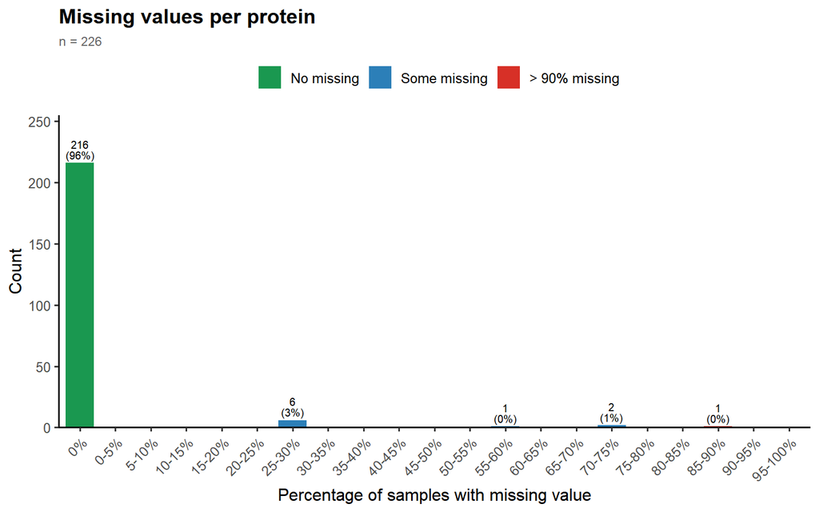

```r
na_prot <- colMeans(is.na(prot))
plot_na_bins(na_prot, "Missing values per protein",
             "Percentage of samples with missing value")
```

## 5.2 Missing values per sample

The missing rate per sample is computed only with the proteins measured in at least 80% of the samples, so that it reflects the quality of the sample and not the changes in the panel. Samples with **more than 5% missing proteins** are flagged as low quality.

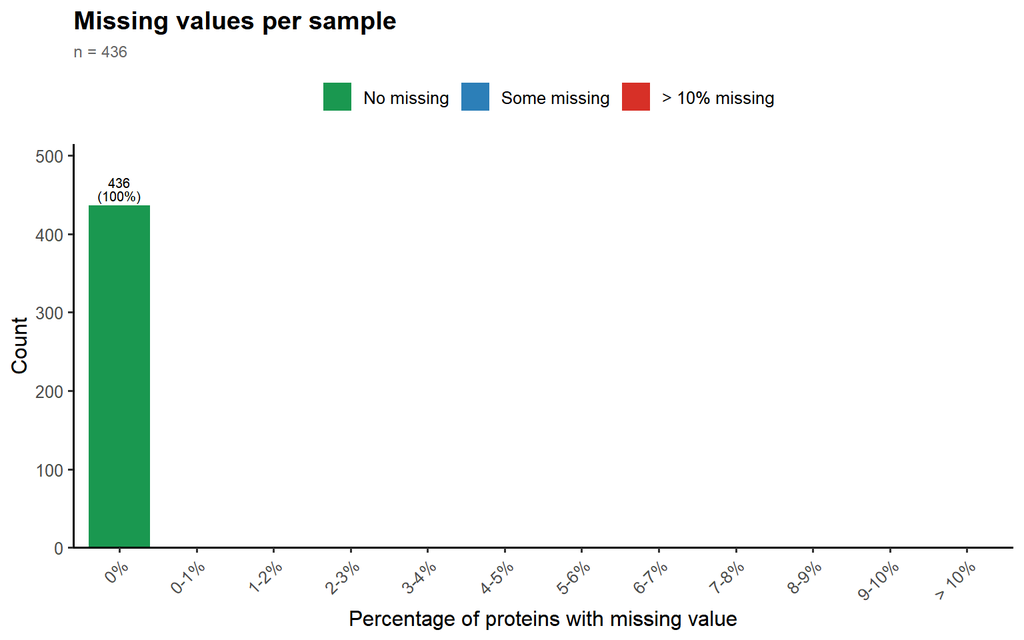

```r
qc_prot   <- names(na_prot)[na_prot <= 0.2]
na_sample <- rowMeans(is.na(prot[, qc_prot]))
plot_na_bins(na_sample, "Missing values per sample",
             "Percentage of proteins with missing value", step = 0.01, max_frac = 0.10)
```

```r
# Samples with more than 5% missing proteins are flagged as low quality
bad_samples <- names(na_sample)[na_sample > 0.05]
bad_samples
```

```
## character(0)
```

Low-quality samples (if any) are listed above: 0 sample(s).

# 6 Data-driven filtering

The two filters below are defined on the training set and saved, so that the test set is filtered with exactly the same rules.

## 6.1 Remove low-quality samples

The samples flagged in the previous step are removed. If any sample is removed here, it should also be removed from the RNA and methylation data to keep the datasets aligned.

```r
prot <- prot[!rownames(prot) %in% bad_samples, , drop = FALSE]
clin <- clin[rownames(prot), ]
# If samples are removed, also remove them from rna and meth to keep all datasets aligned
```

## 6.2 Remove proteins missing in more than 20% of samples

Proteins measured in fewer than 80% of the samples are removed. The number of proteins removed is shown below.

```r
na_prot <- colMeans(is.na(prot))
sum(na_prot > 0.2)                       # number of proteins removed
```

```
## [1] 10
```

```r
prot    <- prot[, na_prot <= 0.2, drop = FALSE]
```

After filtering, **216 proteins** and **436 patients** are kept.

# 7 Distributions per sample and outlier samples

After the TCGA normalisation, all samples should have similar distributions centred around 0. A shifted or much wider distribution may indicate a technical problem, such as a poor protein loading of the sample on the array.

## 7.1 Boxplot per sample

Samples are ordered by their median; the dashed red line marks the cohort median (0).

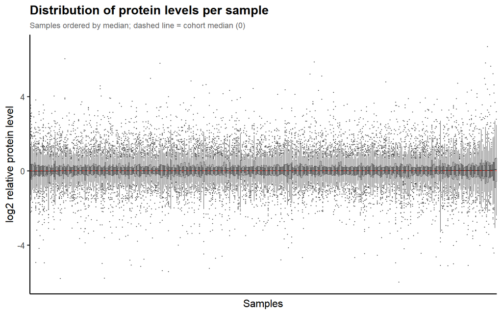

```r
box_df <- data.frame(patientID = rep(rownames(prot), ncol(prot)),
                     value     = as.vector(prot))
box_df$patientID <- factor(box_df$patientID,
                           levels = rownames(prot)[order(rowMedians(prot))])

ggplot(box_df, aes(x = patientID, y = value)) +
  geom_boxplot(outlier.size = 0.2, linewidth = 0.2, fill = "grey85") +
  geom_hline(yintercept = 0, linetype = "dashed", colour = "#D73027") +
  labs(title = "Distribution of protein levels per sample",
       subtitle = "Samples ordered by median; dashed line = cohort median (0)",
       x = "Samples", y = "log2 relative protein level") +
  theme_qc() +
  theme(axis.text.x = element_blank(), axis.ticks.x = element_blank())
```

## 7.2 Median and spread per sample

Each point is a sample, placed by the median and the interquartile range (IQR) of its protein levels. Samples far from the cloud (Tukey far-out fences, 3 × IQR, on the medians or on the IQRs) are flagged as outliers. They are **flagged for inspection, not removed**.

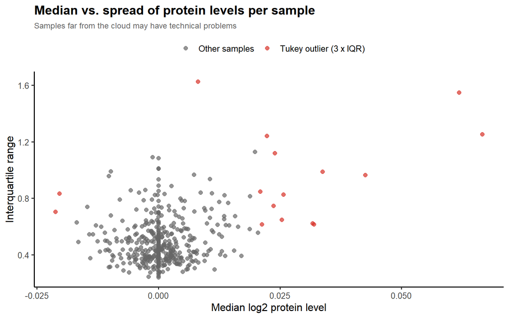

```r
sample_stats <- data.frame(patientID = rownames(prot),
                           median    = rowMedians(prot),
                           iqr       = rowIQRs(prot))

# Tukey fences (Q1 - 3 IQR, Q3 + 3 IQR) on the sample medians and IQRs
tukey_out <- function(x, k = 3) {
  q <- quantile(x, c(0.25, 0.75)); r <- diff(q)
  x < q[1] - k * r | x > q[2] + k * r
}
sample_stats$outlier <- tukey_out(sample_stats$median) | tukey_out(sample_stats$iqr)

ggplot(sample_stats, aes(x = median, y = iqr, colour = outlier)) +
  geom_point(size = 2, alpha = 0.7) +
  scale_colour_manual(values = c(`FALSE` = "grey40", `TRUE` = "#D73027"),
                      labels = c("Other samples", "Tukey outlier (3 x IQR)"), name = NULL) +
  labs(title = "Median vs. spread of protein levels per sample",
       subtitle = "Samples far from the cloud may have technical problems",
       x = "Median log2 protein level", y = "Interquartile range") +
  theme_qc()
```

```r
outlier_samples <- sample_stats$patientID[sample_stats$outlier]
outlier_samples   # flagged for inspection, not removed automatically
```

```
##  [1] "TCGA-AR-A2LE" "TCGA-LL-A740" "TCGA-BH-A0HY" "TCGA-E2-A108" "TCGA-A2-A0YF" "TCGA-E2-A1B5" "TCGA-BH-A0H6" "TCGA-BH-A0GY" "TCGA-EW-A2FW" "TCGA-BH-A0HP"
## [11] "TCGA-E9-A1R6" "TCGA-BH-A0DV" "TCGA-A7-A0D9" "TCGA-D8-A1XK" "TCGA-BH-A0RX" "TCGA-EW-A1PC"
```

16 sample(s) are flagged as outliers.

# 8 Protein variability

Proteins with very low variability carry little information to distinguish patients. With about 200 proteins, all of them are usually kept: this section is descriptive.

## 8.1 Standard deviation of each protein

Histogram of the standard deviation of each protein across samples, for total and phospho-specific proteins. The tables list the most and the least variable proteins.

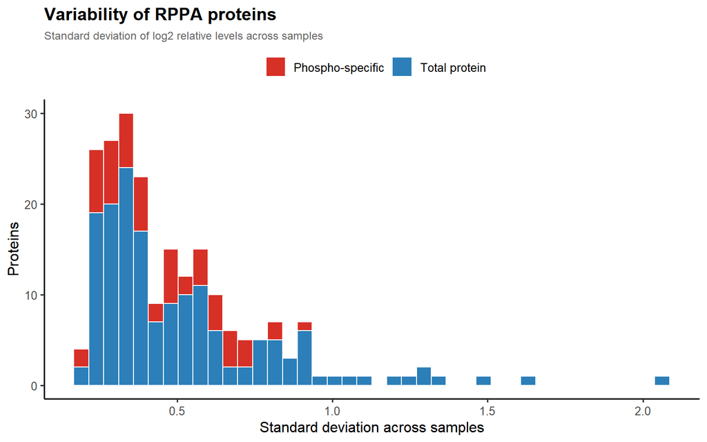

```r
prot_stats <- data.frame(protein = colnames(prot),
                         sd      = colSds(prot),
                         phospho = ifelse(grepl("_p[STY]", colnames(prot)),
                                          "Phospho-specific", "Total protein"))

ggplot(prot_stats, aes(x = sd, fill = phospho)) +
  geom_histogram(bins = 40, colour = "white") +
  scale_fill_manual(values = c(`Total protein` = "#2C7FB8", `Phospho-specific` = "#D73027"),
                    name = NULL) +
  labs(title = "Variability of RPPA proteins",
       subtitle = "Standard deviation of log2 relative levels across samples",
       x = "Standard deviation across samples", y = "Proteins") +
  theme_qc()
```

```r
# Most and least variable proteins
head(prot_stats[order(prot_stats$sd, decreasing = TRUE), ], 10)
```

|  | protein | sd | phospho |
| --- | --- | --- | --- |
| ER-alpha | ER-alpha | 2.062664 | Total protein |
| MYH11 | MYH11 | 1.648586 | Total protein |
| PR | PR | 1.496413 | Total protein |
| GATA3 | GATA3 | 1.347469 | Total protein |
| EPPK1 | EPPK1 | 1.318565 | Total protein |
| E-Cadherin | E-Cadherin | 1.279928 | Total protein |
| Caveolin-1 | Caveolin-1 | 1.240366 | Total protein |
| FASN | FASN | 1.177037 | Total protein |
| Collagen_VI | Collagen_VI | 1.108295 | Total protein |
| GAPDH | GAPDH | 1.072364 | Total protein |

```r
head(prot_stats[order(prot_stats$sd), ], 10)
```

|  | protein | sd | phospho |
| --- | --- | --- | --- |
| FOXO3a_pS318_S321 | FOXO3a_pS318_S321 | 0.1922262 | Phospho-specific |
| 14-3-3_epsilon | 14-3-3_epsilon | 0.2058178 | Total protein |
| LKB1 | LKB1 | 0.2101024 | Total protein |
| p27_pT157 | p27_pT157 | 0.2130259 | Phospho-specific |
| C-Raf | C-Raf | 0.2220333 | Total protein |
| Smad4 | Smad4 | 0.2255869 | Total protein |
| C-Raf_pS338 | C-Raf_pS338 | 0.2269525 | Phospho-specific |
| PKC-delta_pS664 | PKC-delta_pS664 | 0.2322919 | Phospho-specific |
| PDK1 | PDK1 | 0.2349278 | Total protein |
| MIG-6 | MIG-6 | 0.2352506 | Total protein |

## 8.2 Distribution across patients of random proteins

Because the RPPA values are median-centred (all medians are close to 0), the proteins are stratified by their variability (tertiles of SD) instead of their mean level, and four random proteins are shown from each tertile.

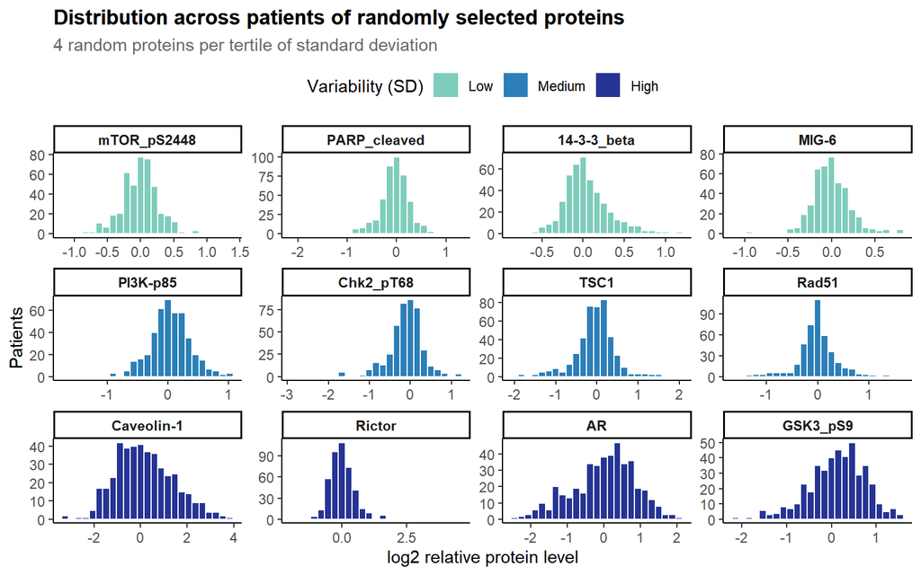

```r
set.seed(1)
strata <- cut(prot_stats$sd, quantile(prot_stats$sd, c(0, 1/3, 2/3, 1)),
              labels = c("Low", "Medium", "High"), include.lowest = TRUE)
names(strata) <- prot_stats$protein
pick <- unlist(lapply(split(prot_stats$protein, strata), sample, size = 4))

prot_df_long <- data.frame(protein = rep(pick, each = nrow(prot)),
                           stratum = rep(strata[pick], each = nrow(prot)),
                           value   = as.vector(prot[, pick]))
prot_df_long$protein <- factor(prot_df_long$protein, levels = pick)

ggplot(prot_df_long, aes(value, fill = stratum)) +
  geom_histogram(bins = 25, colour = "white") +
  facet_wrap(~ protein, scales = "free", ncol = 4) +
  scale_fill_manual(values = c(Low = "#7FCDBB", Medium = "#2C7FB8", High = "#253494"),
                    name = "Variability (SD)") +
  labs(title = "Distribution across patients of randomly selected proteins",
       subtitle = "4 random proteins per tertile of standard deviation",
       x = "log2 relative protein level", y = "Patients") +
  theme_classic(base_size = 11) +
  theme(plot.title    = element_text(face = "bold"),
        plot.subtitle = element_text(colour = "grey40"),
        strip.text    = element_text(face = "bold"),
        legend.position = "top")
```

# 9 Duplicated or mixed-up samples

Two different patients should never have near-identical protein profiles. Pairs of samples with a correlation above 0.99 would suggest a duplicated sample. The histogram shows, for each sample, its highest correlation with any other sample: values close to 1 suggest duplicates, and values far to the left a sample unlike any other.

```r
cor_mat <- cor(t(prot))                 # sample x sample correlation
diag(cor_mat) <- NA                     # ignore self-correlation

dup_pairs <- which(cor_mat > 0.99, arr.ind = TRUE)
dup_pairs <- dup_pairs[dup_pairs[, 1] < dup_pairs[, 2], , drop = FALSE]   # each pair once
data.frame(sample1 = rownames(cor_mat)[dup_pairs[, 1]],
           sample2 = colnames(cor_mat)[dup_pairs[, 2]],
           r       = cor_mat[dup_pairs])
```

| sample1 | sample2 | r |
| --- | --- | --- |

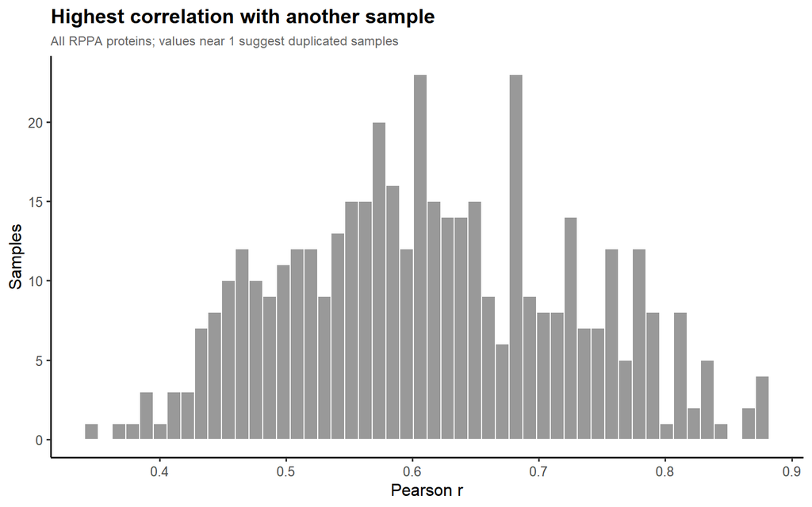

```r
max_cor <- data.frame(patientID = rownames(cor_mat),
                      max_r     = apply(cor_mat, 1, max, na.rm = TRUE))

ggplot(max_cor, aes(x = max_r)) +
  geom_histogram(bins = 50, fill = "grey60", colour = "white") +
  labs(title = "Highest correlation with another sample",
       subtitle = "All RPPA proteins; values near 1 suggest duplicated samples",
       x = "Pearson r", y = "Samples") +
  theme_qc()
```

0 pair(s) of samples have a correlation above 0.99.

# 10 Principal component analysis

The PCA is **centred but not scaled**, because all proteins are on the same (log2 relative) scale.

```r
pc      <- prcomp(prot, center = TRUE, scale. = FALSE)
var_exp <- round(100 * summary(pc)$importance[2, 1:2], 1)

pca_df <- data.frame(PC1     = pc$x[, 1],
                     PC2     = pc$x[, 2],
                     stage   = clin[rownames(prot), "outcome_p.stage"],
                     outlier = rownames(prot) %in% outlier_samples)
```

## 10.1 PCA coloured by stage

Shows whether the main sources of variation in the protein data are related to the outcome.

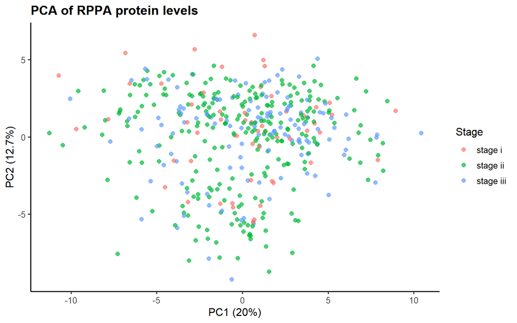

```r
ggplot(pca_df, aes(x = PC1, y = PC2, colour = stage)) +
  geom_point(size = 2, alpha = 0.7) +
  labs(title = "PCA of RPPA protein levels",
       x = paste0("PC1 (", var_exp[1], "%)"), y = paste0("PC2 (", var_exp[2], "%)"),
       colour = "Stage") +
  theme_qc() +
  theme(legend.position = "right")
```

## 10.2 PCA and outlier samples

The outlier samples flagged above are highlighted. If they are also far from the rest in the PCA, their profile is globally different; if they are inside the cloud, the outlier flag is probably due to a few proteins only.

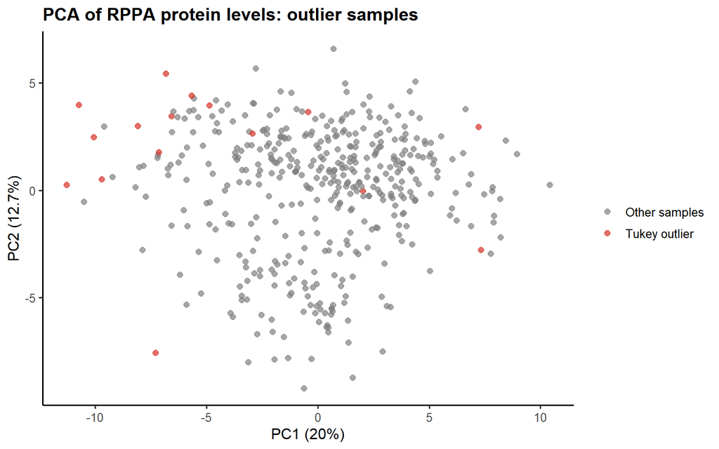

```r
ggplot(pca_df, aes(x = PC1, y = PC2, colour = outlier)) +
  geom_point(size = 2, alpha = 0.7) +
  scale_colour_manual(values = c(`FALSE` = "grey50", `TRUE` = "#D73027"),
                      labels = c("Other samples", "Tukey outlier"), name = NULL) +
  labs(title = "PCA of RPPA protein levels: outlier samples",
       x = paste0("PC1 (", var_exp[1], "%)"), y = paste0("PC2 (", var_exp[2], "%)")) +
  theme_qc() +
  theme(legend.position = "right")
```

## 10.3 Proteins that drive the first components

The 10 proteins with the largest absolute loadings in PC1 and PC2.

```r
head(sort(abs(pc$rotation[, 1]), decreasing = TRUE), 10)
```

```
##    ER-alpha       MYH11       GATA3  Caveolin-1 Collagen_VI       RBM15       HSP70       GAPDH       EPPK1  E-Cadherin
##   0.2785260   0.2514503   0.2371802   0.2260350   0.2256453   0.1734004   0.1694640   0.1657266   0.1502648   0.1459839
```

```r
head(sort(abs(pc$rotation[, 2]), decreasing = TRUE), 10)
```

```
##    ER-alpha          PR       GATA3       MYH11  Caveolin-1       Bcl-2      INPP4B          AR   Cyclin_B1 Collagen_VI
##   0.5375731   0.2856936   0.2735412   0.2379969   0.1964321   0.1802690   0.1788532   0.1675425   0.1652062   0.1491999
```

# 11 RNA–protein concordance (sample identity check)

For several proteins measured both as RNA and as protein, the gene expression and the protein level of the same patient should be positively correlated. This is a check of **sample identity**: a patient whose RNA and protein disagree for several markers may be a sample swap. Protein names differ between panel versions, so the mapping between proteins and genes may need to be adjusted (see the comments in the code).

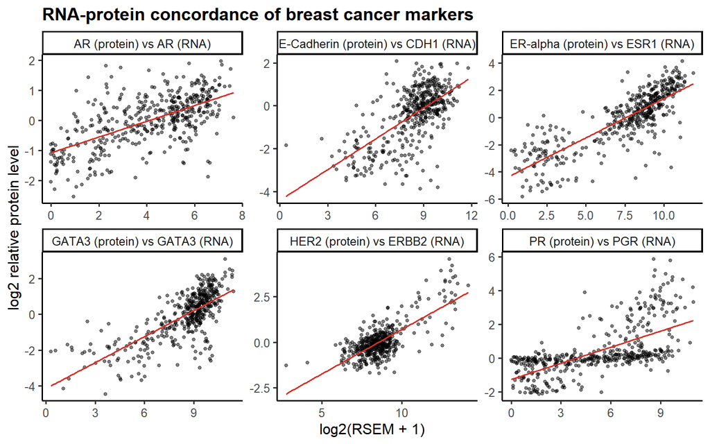

```r
do_rna_check <- TRUE
if (do_rna_check) {
  df  <- readRDS(file.path(path.x, "rna.train.rds"))
  rna <- as.matrix(df[, colnames(df) != "patientID"])
  rownames(rna) <- df$patientID
  rm(df)

  # Find the antibody names of the markers in this dataset
  grep("ER|PR|HER2|AR|GATA3|CDH1|E-Cad", colnames(prot), value = TRUE, ignore.case = TRUE)

  # Antibody -> gene mapping (adjust the antibody names to those found above)
  markers <- c(`ER-alpha`   = "ESR1",
               `PR`         = "PGR",
               `HER2`       = "ERBB2",
               `AR`         = "AR",
               `GATA3`      = "GATA3",
               `E-Cadherin` = "CDH1")
  markers <- markers[names(markers) %in% colnames(prot) & markers %in% colnames(rna)]

  common <- intersect(rownames(prot), rownames(rna))
  concord <- data.frame(antibody = names(markers),
                        gene     = markers,
                        r        = sapply(names(markers), function(a) {
                          cor(prot[common, a], rna[common, markers[a]], method = "spearman")
                        }))
  concord   # expected: clearly positive correlations (e.g. ER, PR, HER2 > 0.6)

  # Scatter plots of protein vs. RNA for each marker
  conc_df <- do.call(rbind, lapply(names(markers), function(a) {
    data.frame(marker  = sprintf("%s (protein) vs %s (RNA)", a, markers[a]),
               protein = prot[common, a],
               rna     = rna[common, markers[a]])
  }))

  ggplot(conc_df, aes(x = rna, y = protein)) +
    geom_point(size = 1, alpha = 0.5) +
    geom_smooth(method = "lm", se = FALSE, colour = "#D73027", linewidth = 0.6) +
    facet_wrap(~ marker, scales = "free") +
    labs(title = "RNA-protein concordance of breast cancer markers",
         x = "log2(RSEM + 1)", y = "log2 relative protein level") +
    theme_qc()
}
```

Clearly positive correlations for the markers indicate that the RNA and protein samples come from the same patients.

# 12 Summary

- **216 proteins and 436 patients** are kept for the models; 0 low-quality sample(s) were removed.
- 16 sample(s) were flagged as outliers by their median or spread and kept.
- No duplicated samples were detected (no pair of samples with r > 0.99).

# 13 Save

The filtered data and the QC parameters are written by the R script `02_qc_prot.R`. In this report the code is shown but **not run**, so that knitting does not overwrite the processed data (nor the model cache that depends on them).

```r
path.x <- "./data/processed"
dir.create(path.x, showWarnings = FALSE, recursive = TRUE)

prot_df <- data.frame(prot, check.names = FALSE)
prot_df$patientID <- rownames(prot_df)
prot_df <- prot_df[, c(ncol(prot_df), 1:(ncol(prot_df) - 1))]   # patientID as first column

# QC parameters learned on train, to apply the same QC to test / Shiny data
prot_qc_params <- list(
  kept_proteins = colnames(prot),   # Proteins kept after filtering (step 4b)
  max_na_sample = 0.05              # Max fraction of missing proteins per sample (step 3b)
)

saveRDS(prot_df, file.path(path.x, "prot.train.filtered.rds"))
saveRDS(prot_qc_params, file.path(path.x, "prot_qc_params.rds"))   # QC parameters for test / Shiny
```